# PCA

```r
library(haven)
library(psych)
library(ggplot2)
library(GGally)
library(factoextra)
```

Возьмем данные по Украине

Украина как объект исследования по демократическим ценностям актуальна, так как в различные периоды и по-разным оценкам Украина имела некоторый shift в демократическим ценностям, что усложнялось с ситуацией на снг пространстве. Данные по демократическим ценностям в стране взяты за 2011 год, то есть до протестных событий, что интересно так как покажет оценку ценностей в относительно нейтральный период. Также так как набор показателей содержит условно несколько кластеров ценностей ( экономические, выборы и гражданские права, религия и армия ) можно предположить, что из-за неоднородности направленности к демократическим ценностям в стране ( влияние России с одной стороны до определенного времени, Европы с другой) могут получится достаточно четко разделенные компоненты по этим кластерам, где будут условно демократические ценности и допустим ценности религии и армии.

```r
library(readxl)
df <- read_excel("C:/Users/Anastasia/Downloads/F00007630-WV6_Data_Ukraine_2011_Excel_v20180912.xlsx")
df <- df[,152:160]
```

```r
df <- na.omit(df)
```

# Зафиксируем названия переменных для дальнейшей интерпретация

```r
var_names <- colnames(df)
var_names
```

```
## [1] "V131: Democracy: Governments tax the rich and subsidize the poor."
## [2] "V132: Democracy: Religious authorities interpret the laws."
## [3] "V133: Democracy: People choose their leaders in free elections."
## [4] "V134: Democracy: People receive state aid for unemployment."
## [5] "V135: Democracy: The army takes over when government is incompetent."
## [6] "V136: Democracy: Civil rights protect people’s liberty from state oppression"
## [7] "V137: Democracy: The state makes people's incomes equal"
## [8] "V138: Democracy: People obey their rulers"
## [9] "V139: Democracy: Women have the same rights as men."
```

```r
colnames(df) <- c('V131','V132','V133','V134','V135','V136','V137','V138','V139')
```

# Реализуем МГК

Реализуем МГК так чтобы признаки стали нескоррелированными (то есть ортогональными) и стандартизуем данные для более легкой интерпретации как весов компонент, так и собственных значений.

```r
pca_results <- prcomp(df, center = TRUE, scale = TRUE)
summary(pca_results)
```

```
## Importance of components:
##                          PC1    PC2    PC3     PC4    PC5     PC6     PC7
## Standard deviation     1.755 1.2298 0.9635 0.85516 0.8287 0.78238 0.73446
## Proportion of Variance 0.342 0.1680 0.1031 0.08126 0.0763 0.06801 0.05994
## Cumulative Proportion  0.342 0.5101 0.6132 0.69447 0.7708 0.83878 0.89872
##                            PC8     PC9
## Standard deviation     0.69751 0.65196
## Proportion of Variance 0.05406 0.04723
## Cumulative Proportion  0.95277 1.00000
```

Мы можем сразу увидеть, что кумулятивная доля объясненной вариаци в 0.75 набирается только к пятой главной компоненте, что ставит вопрос о том, насколько целесообразно снижение размерности. # Выпишем собственные значения компонент

```r
std_dev <- pca_results$sdev
var <- std_dev^2
var
```

```
## [1] 3.0783391 1.5123081 0.9282684 0.7313011 0.6866768 0.6121115 0.5394319
## [8] 0.4865138 0.4250495
```

Таким образом, собственные значения показывают вариацию главных компонент, где первое значение - вариация самой первой и самой информативной компоненты, 2 - второй и менее информативной и так далее. Поэтому 3.07 - вариация первой компоненты, 1.51 - второй. Рассчитаем информативность ( то есть какую долю общей вариации объясняет отдельная компонента) каждой отдельной компоненты:

```r
var[1]/sum(var)
```

```
## [1] 0.3420377
```

```r
var[2]/sum(var)
```

```
## [1] 0.1680342
```

```r
var[3]/sum(var)
```

```
## [1] 0.1031409
```

```r
var[4]/sum(var)
```

```
## [1] 0.08125568
```

```r
var[5]/sum(var)
```

```
## [1] 0.07629742
```

```r
var[6]/sum(var)
```

```
## [1] 0.06801238
```

```r
var[7]/sum(var)
```

```
## [1] 0.05993688
```

```r
var[8]/sum(var)
```

```
## [1] 0.05405709
```

```r
var[9]/sum(var)
```

```
## [1] 0.04722772
```

Как мы можем увидеть доля объясненной вариации ( информативность) первой главной компоненты составляем 0,34, что не является достаточной долей вариации для компоненты -> МГК в первоначальном виде не совсем целесообразен. Возможно это связано с несильной коррелированностью показателей в целом и решением данной проблемы могло бы быть предварительное разбиение показателей на группы и суб-группы и уже последовательного проведения МГК по этим группам.

Посмотрим так же на сами данные, чтобы понять целесообразность МГК:

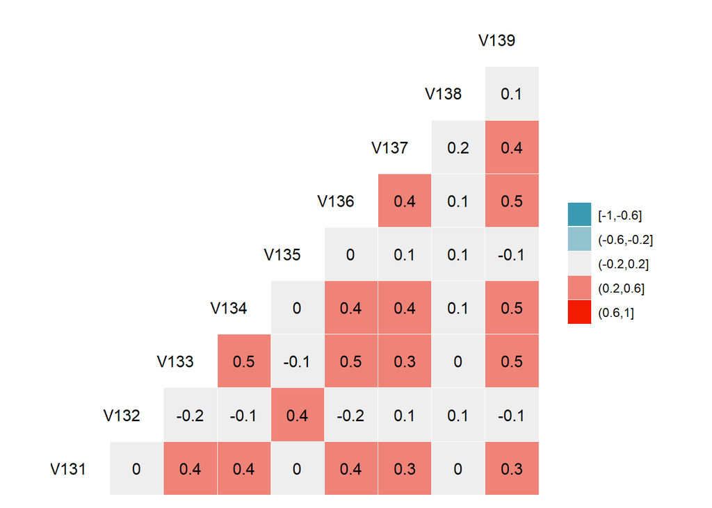

```r
ggcorr(df, nbreaks = 5, label = T, size = 4, hjust = 0.9)
```

Как можно увидеть нет сильных корреляций в датасете( максимальные 0,5), что тоже говорит о нецелесообразности проведения МГК на всем датасете, однако возможно ситуация улучшилась бы если мы предварительно разбили его на группы, основываясь на наиболее скоррелированных показателях ( например, 133 и 136 оба относятся к гражданским правам и выборам - можно объединить). Для удобства выведу название переменных.

```r
var_names
```

```
## [1] "V131: Democracy: Governments tax the rich and subsidize the poor."
## [2] "V132: Democracy: Religious authorities interpret the laws."
## [3] "V133: Democracy: People choose their leaders in free elections."
## [4] "V134: Democracy: People receive state aid for unemployment."
## [5] "V135: Democracy: The army takes over when government is incompetent."
## [6] "V136: Democracy: Civil rights protect people’s liberty from state oppression"
## [7] "V137: Democracy: The state makes people's incomes equal"
## [8] "V138: Democracy: People obey their rulers"
## [9] "V139: Democracy: Women have the same rights as men."
```

## Задание №2.

```r
pca_results
```

```
## Standard deviations (1, .., p=9):
## [1] 1.7545196 1.2297594 0.9634668 0.8551615 0.8286596 0.7823755 0.7344603
## [8] 0.6975054 0.6519582
##
## Rotation (n x k) = (9 x 9):
##              PC1           PC2         PC3         PC4         PC5         PC6
## V131 -0.36033315  0.0428505371 -0.32664062  0.66578711 -0.02865721  0.36269367
## V132  0.09263547  0.6170934406 -0.30048922  0.25373580 -0.10605379 -0.57975886
## V133 -0.43466791 -0.1201274418 -0.01667935  0.04056698  0.34936626 -0.06205516
## V134 -0.42688859  0.0537582653 -0.11279527  0.10006772  0.20033381 -0.03500751
## V135  0.05649861  0.6091174362 -0.24902632 -0.42338274  0.39777639  0.42879285
## V136 -0.43632928 -0.0198511028  0.04700130 -0.33000154 -0.02971730  0.11444152
## V137 -0.34266433  0.2664006508  0.07863448 -0.19928829 -0.78752913  0.16150309
## V138 -0.05825020  0.3970527089  0.84428571  0.29871681  0.16346454  0.08629100
## V139 -0.41954901 -0.0008281893  0.08237833 -0.25216051  0.14038865 -0.54476329
##              PC7         PC8         PC9
## V131 -0.23334744 -0.35980575 -0.04558662
## V132 -0.17554214  0.24374734  0.13543698
## V133 -0.16155814  0.59383897 -0.53856842
## V134  0.76612736  0.12458197  0.38510894
## V135  0.02210482 -0.13575395 -0.15332866
## V136 -0.51841303  0.15600723  0.62533371
## V137  0.17191905  0.08518608 -0.28742727
## V138 -0.02987033 -0.01960314  0.03824463
## V139 -0.04463936 -0.62654076 -0.20636091
```